# Remaking our Heartlands

Wan E Lynn (P1728600) DFI3A04_Group1

22 July, 2019

## Background

“Remaking our Heartland” is a program by HDB to renew and further develop existing HDB towns and estates, and to ensure sustainability and vibrancy of the HDB heartlands. This generally includes building more ammenities within the neighbourhood to give residents a higher standard of living.

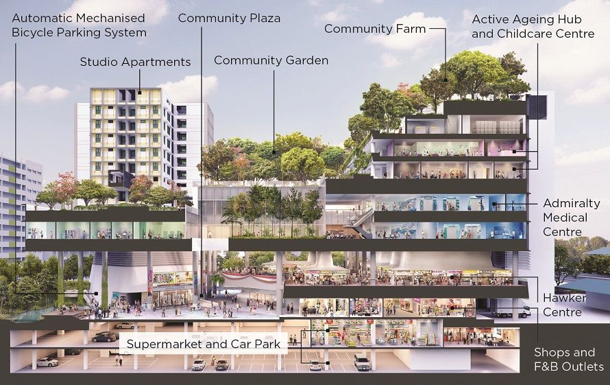

## A closer look at ROH’s impact

### Remaking our Heartland" proves to be a big success

[interactive chart not shown]

This stacked bar graph shows the differences in average prices of flats that have undergone the “Remaking our Heartland” program. A stacked bar chart was chosen to better show the relative difference between the prices. The graph is also sorted from highest to lowest Price after ROH.

The years used to compute Prices before ROH are from 1990 to 1 year before ROH, and the years used to compute Prices after ROH are from the year of their respective ROH commencement year to 2017.

You may hover your mouse above the bars to see the exact average price of these flats.

**All flats that were improved under the ROH program have seen an increase in average resale price** over the years and **thus appreciated in value due to ROH.** Top 3 Towns that show greatest appreciation, from most to least, are Queenstown, Marine Parade and Toa Payoh.

### Queenstown demonstrates highest resale price appreciation due to ROH

[interactive chart not shown]

This line graph drills down to show the increase in resale prices of flats in Queenstown, which showed the greatest price increase due to ROH.

Queenstown showed the most aggressive price increase during 2006-2008. **This may be credited to ROH-Queenstown** which took place from 2007 onwards and resale **prices showed an upward trend for the next 10 years till 2017.**